# Notebook

**Lineare Regression**

Dr. Matthias Hölzl

## Lineare Regression mit mehreren Features

Bei fast allen Machine Learning Projekten hängen die Labels von mehreren Features ab.

Im folgenden Beispiel wollen wir die Note eines Studenten in der Abschlussprüfung vorhersagen. Dabei beziehen wir folgende Labels mit ein:

- Note in der Zwischenprüfung
- Anzahl der Stunden, die für das Lernen aufgewendet wurden
- Anzahl der versäumten Kurstage

Die Daten sind in der sqlite Datenbank `student_grades.db` gespeichert.

- Laden Sie die Daten aus der Datenbank in "DB Browser for SQLite" und analysieren Sie die Struktur der Daten.
- Verwenden Sie anschließend die `sqlite3` Bibliothek, um die Daten aus der Datenbank zu laden.
  - Erzeugen Sie eine Liste `student_x` mit den Features als Listen von numerischen Werten
  - Erzeugen Sie eine Liste `student_y` mit den Labels als numerischen Werten

Mit dem DB Browser sehen wir, dass die Daten in einer Tabelle `grades` mit den Spalten `midterm_grade`, `study_hours`, `missed_classes` und `final_grade` gespeichert sind.

- Um die `student_x` Liste zu erzeugen, verwenden wir die Spalten `midterm_grade`, `study_hours` und `missed_classes`.

```python
import sqlite3
```

```python
connection = sqlite3.connect("student_grades.db")
cursor = connection.cursor()
```

```python
cursor.execute(
    "SELECT midterm_grade, study_hours, missed_classes, final_grade FROM grades"
)
rows = cursor.fetchall()
connection.close()
```

```python
rows[:5]
```

```
[(68.61414733989902, 24.354372812131615, 2, 99.45150152252683),
 (81.0142835772731, 27.26909615832836, 3, 98.71158127271742),
 (48.416769622930246, 3.589394910795301, 2, 40.197655623816786),
 (60.0486696258521, 18.341308240388855, 4, 76.01285722265153),
 (68.48907867560497, 15.558488977468924, 2, 70.57094667918675)]
```

```python
student_x = [list(row[:3]) for row in rows]
```

```python
student_x[:5]
```

```
[[68.61414733989902, 24.354372812131615, 2],
 [81.0142835772731, 27.26909615832836, 3],
 [48.416769622930246, 3.589394910795301, 2],
 [60.0486696258521, 18.341308240388855, 4],
 [68.48907867560497, 15.558488977468924, 2]]
```

```python
student_y = [row[3] for row in rows]
```

```python
student_y[:5]
```

```
[99.45150152252683,
 98.71158127271742,
 40.197655623816786,
 76.01285722265153,
 70.57094667918675]
```

Plotten Sie die Daten in Scatterplots, um die Beziehungen zwischen den einzelnen Features und den Labels zu visualisieren.

```python
import matplotlib.pyplot as plt
import seaborn as sns
```

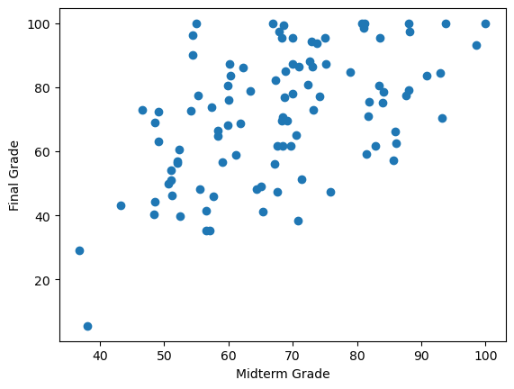

```python
plt.scatter([x[0] for x in student_x], student_y)
plt.xlabel("Midterm Grade")
plt.ylabel("Final Grade")
plt.show()
```

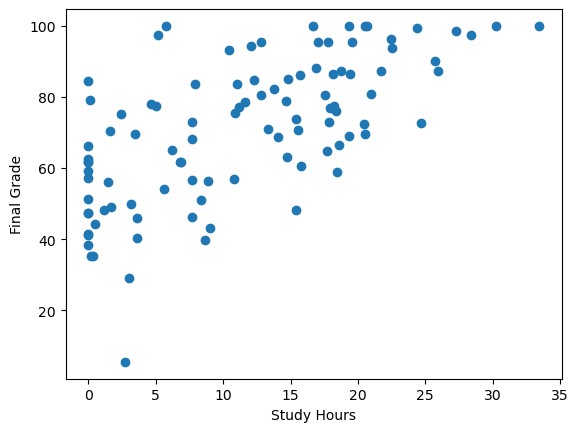

```python
plt.scatter([x[1] for x in student_x], student_y)
plt.xlabel("Study Hours")
plt.ylabel("Final Grade")
plt.show()
```

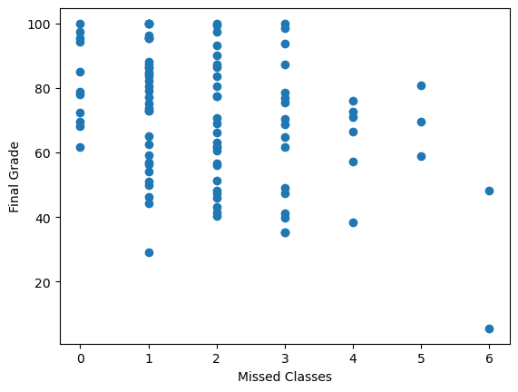

```python
plt.scatter([x[2] for x in student_x], student_y)
plt.xlabel("Missed Classes")
plt.ylabel("Final Grade")
plt.show()
```

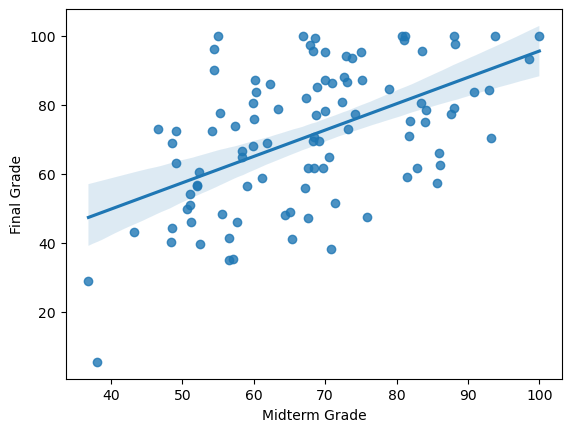

```python
sns.regplot(x=[x[0] for x in student_x], y=student_y)
plt.xlabel("Midterm Grade")
plt.ylabel("Final Grade")
plt.show()
```

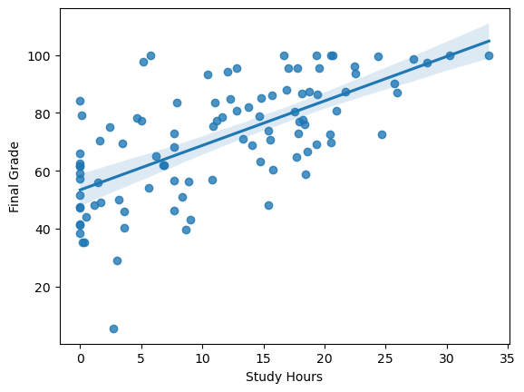

```python
sns.regplot(x=[x[1] for x in student_x], y=student_y)
plt.xlabel("Study Hours")
plt.ylabel("Final Grade")
plt.show()
```

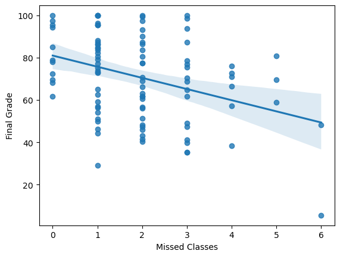

```python
sns.regplot(x=[x[2] for x in student_x], y=student_y)
plt.xlabel("Missed Classes")
plt.ylabel("Final Grade")
plt.show()
```

Trainieren Sie nun ein lineares Regressionsmodell mit den Daten in `student_x` und `student_y`.

(Ein solches Modell mit mehreren Features wird auch als multivariates lineares Modell bezeichnet.)

```python
from sklearn.model_selection import train_test_split
```

```python
student_x_train, student_x_test, student_y_train, student_y_test = train_test_split(
    student_x, student_y, test_size=0.4, random_state=42
)
```

```python
student_x_train[:5], student_y_train[:5]
```

```
([[86.03980444978299, 0.0, 1],
  [81.22833322956463, 20.50946492959092, 1],
  [66.88943301907211, 20.69123987775948, 1],
  [61.11618696515874, 18.423860062696207, 5],
  [70.99383353908377, 19.385388995680746, 2]],
 [62.6072717805467, 100.0, 100.0, 58.85557798007585, 86.39053201735675])
```

```python
from sklearn.linear_model import LinearRegression
```

```python
model = LinearRegression()
model.fit(student_x_train, student_y_train)
```

```
LinearRegression()
```

Bewerten Sie das Modell mit dem Mean Absolute Error (MAE) und dem Mean Squared Error (MSE).

```python
from sklearn.metrics import mean_absolute_error, mean_squared_error
```

```python
train_predictions = model.predict(student_x_train)
test_predictions = model.predict(student_x_test)
```

```python
mean_absolute_error(student_y_train, train_predictions)
```

```
4.161008983291446
```

```python
mean_squared_error(student_y_train, train_predictions)
```

```
28.16280374809613
```

```python
mean_absolute_error(student_y_test, test_predictions)
```

```
3.5150116480605176
```

```python
mean_squared_error(student_y_test, test_predictions)
```

```
19.190275959855565
```

Plotten Sie die Vorhersagen gegen die tatsächlichen Werte in einem Scatterplot.

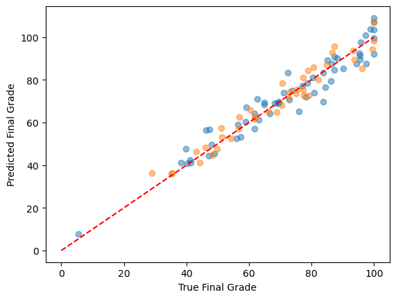

```python
plt.scatter(student_y_train, train_predictions, alpha=0.5)
plt.scatter(student_y_test, test_predictions, alpha=0.5)
plt.plot([0, 100], [0, 100], color="red", linestyle="--")
plt.xlabel("True Final Grade")
plt.ylabel("Predicted Final Grade")
plt.show()
```

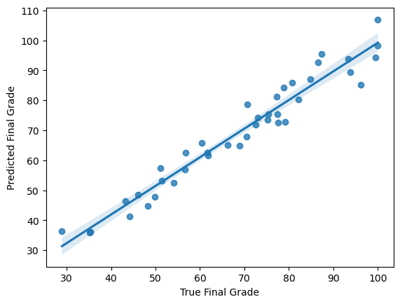

```python
sns.regplot(x=student_y_test, y=test_predictions)
plt.xlabel("True Final Grade")
plt.ylabel("Predicted Final Grade")
plt.show()
```

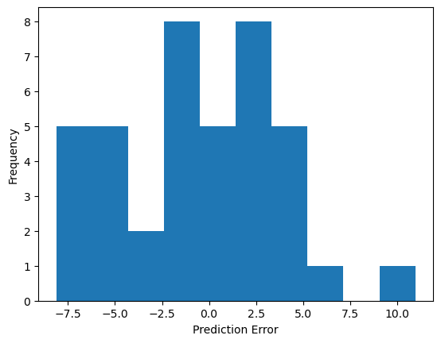

```python
error = [true - pred for true, pred in zip(student_y_test, test_predictions)]
plt.hist(error, bins=10)
plt.xlabel("Prediction Error")
plt.ylabel("Frequency")
plt.show()
```

## Workshop: Eiscreme

In diesem Workshop werden wir ein kleines Machine Learning Projekt durchführen.

Wir werden den Verkauf von Eiscreme basierend auf der Temperatur und der Bewölkung vorhersagen.

Die Daten sind in der sqlite Datenbank `ice_cream_sales.db` gespeichert.

- Laden Sie die Daten aus der Datenbank in "DB Browser for SQLite" und analysieren Sie die Struktur der Daten.
- Verwenden Sie anschließend die `sqlite3` Bibliothek, um die Daten aus der Datenbank zu laden.
  - Erzeugen Sie eine Liste `ice_cream_x` mit den Features als Listen von numerischen Werten
  - Erzeugen Sie eine Liste `ice_cream_y` mit den Labels als numerischen Werten

```python
import sqlite3
```

```python
connection = sqlite3.connect("ice_cream_sales.db")
cursor = connection.cursor()
```

```python
cursor.execute("SELECT temperature, cloud_cover, sales FROM sales")
data = cursor.fetchall()
connection.close()
```

```python
ice_cream_x = [list(row[:2]) for row in data]
ice_cream_y = [row[2] for row in data]
```

```python
ice_cream_x[:5]
```

```
[[22.133333333333333, 71.22222222222223],
 [18.733333333333334, 84.22222222222223],
 [11.855555555555556, 100.0],
 [16.455555555555556, 81.0],
 [17.433333333333334, 66.22222222222223]]
```

```python
ice_cream_y[:5]
```

```
[1491, 1104, 41, 769, 1071]
```

Plotten Sie die Daten in Scatterplots, um die Beziehungen zwischen den einzelnen Features und den Labels zu visualisieren.

```python
import matplotlib.pyplot as plt
import seaborn as sns
```

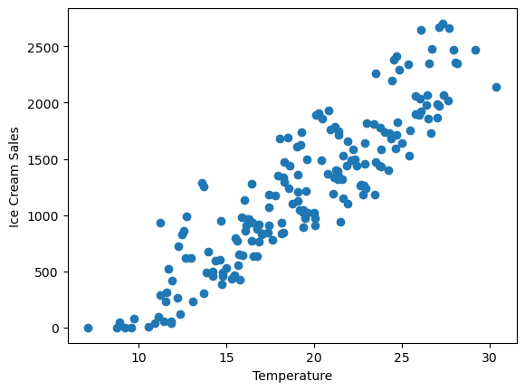

```python
plt.scatter([x[0] for x in ice_cream_x], ice_cream_y)
plt.xlabel("Temperature")
plt.ylabel("Ice Cream Sales")
plt.show()
```

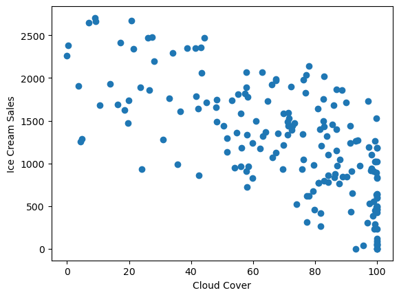

```python
plt.scatter([x[1] for x in ice_cream_x], ice_cream_y)
plt.xlabel("Cloud Cover")
plt.ylabel("Ice Cream Sales")
plt.show()
```

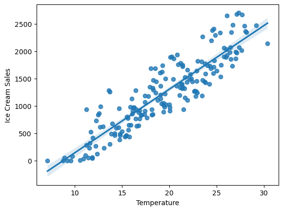

```python
sns.regplot(x=[x[0] for x in ice_cream_x], y=ice_cream_y)
plt.xlabel("Temperature")
plt.ylabel("Ice Cream Sales")
plt.show()
```

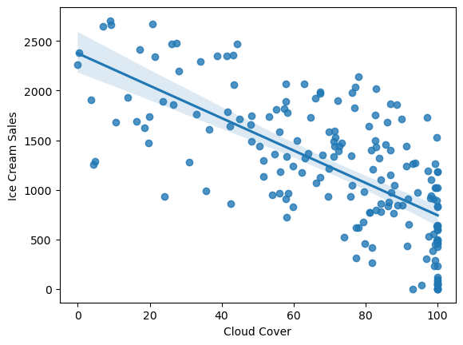

```python
sns.regplot(x=[x[1] for x in ice_cream_x], y=ice_cream_y)
plt.xlabel("Cloud Cover")
plt.ylabel("Ice Cream Sales")
plt.show()
```

Trainieren Sie nun ein lineares Regressionsmodell mit den Daten in `ice_cream_x` und `ice_cream_y`.

```python
from sklearn.model_selection import train_test_split
```

```python
ice_cream_x_train, ice_cream_x_test, ice_cream_y_train, ice_cream_y_test = train_test_split(
    ice_cream_x, ice_cream_y, test_size=0.4, random_state=42
)
```

```python
from sklearn.linear_model import LinearRegression
```

```python
model = LinearRegression()
model.fit(ice_cream_x_train, ice_cream_y_train)
```

```
LinearRegression()
```

Bewerten Sie das Modell mit dem Mean Absolute Error (MAE) und dem Mean Squared Error (MSE).

```python
from sklearn.metrics import mean_absolute_error, mean_squared_error
```

```python
train_predictions = model.predict(ice_cream_x_train)
test_predictions = model.predict(ice_cream_x_test)
```

```python
mean_absolute_error(ice_cream_y_train, train_predictions)
```

```
80.71995023163682
```

```python
mean_squared_error(ice_cream_y_train, train_predictions)
```

```
9692.044423769326
```

```python
mean_absolute_error(ice_cream_y_test, test_predictions)
```

```
81.64573733285214
```

```python
mean_squared_error(ice_cream_y_test, test_predictions)
```

```
9781.232527384587
```

Plotten Sie die Vorhersagen gegen die tatsächlichen Werte in einem Scatterplot.

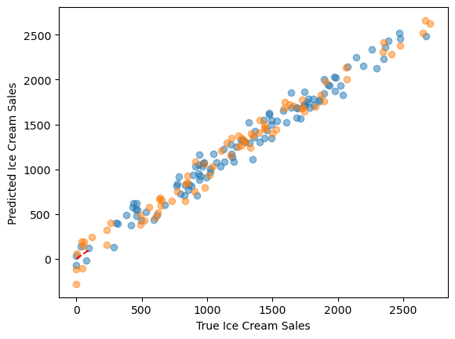

```python
plt.scatter(ice_cream_y_train, train_predictions, alpha=0.5)
plt.scatter(ice_cream_y_test, test_predictions, alpha=0.5)
plt.plot([0, 100], [0, 100], color="red", linestyle="--")
plt.xlabel("True Ice Cream Sales")
plt.ylabel("Predicted Ice Cream Sales")
plt.show()
```

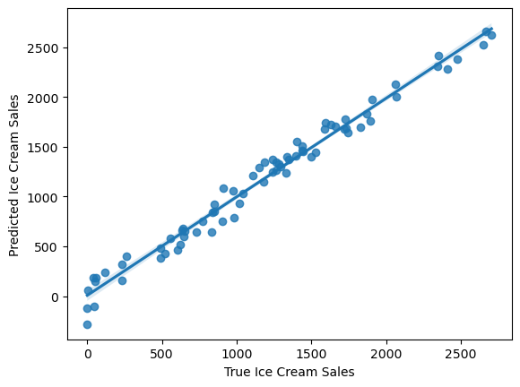

```python
sns.regplot(x=ice_cream_y_test, y=test_predictions)
plt.xlabel("True Ice Cream Sales")
plt.ylabel("Predicted Ice Cream Sales")
plt.show()
```

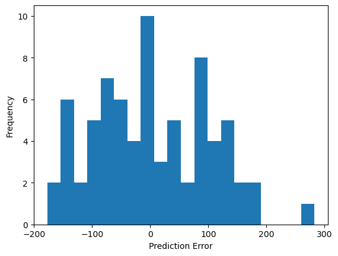

```python
error = [true - pred for true, pred in zip(ice_cream_y_test, test_predictions)]
plt.hist(error, bins=20)
plt.xlabel("Prediction Error")
plt.ylabel("Frequency")
plt.show()
```